# MBA Admission Prediction

## Decision Tree, Random Forest, and Gradient Boosting

**Course:** CPE342 Machine Learning - Lab 4  
**Instructor:** Asst. Prof. Dr. Santitham Prom-on  
**Student Name / ID:** Siriwan Yondeephot 67070501075

# 1. Load Data

```python
import pandas as pd
import numpy as np
import matplotlib.pyplot as plt
import seaborn as sns
pd.set_option('display.max_columns', 100)

df = pd.read_csv('MBA.csv')
print(f'Shape: {df.shape}')
df.head(10)
```

```
Shape: (6194, 10)
```

|  | application_id | gender | international | gpa | major | race | gmat | work_exp | work_industry | admission |
| --- | --- | --- | --- | --- | --- | --- | --- | --- | --- | --- |
| 0 | 1 | Female | False | 3.30 | Business | Asian | 620.0 | 3.0 | Financial Services | Admit |
| 1 | 2 | Male | False | 3.28 | Humanities | Black | 680.0 | 5.0 | Investment Management | NaN |
| 2 | 3 | Female | True | 3.30 | Business | NaN | 710.0 | 5.0 | Technology | Admit |
| 3 | 4 | Male | False | 3.47 | STEM | Black | 690.0 | 6.0 | Technology | NaN |
| 4 | 5 | Male | False | 3.35 | STEM | Hispanic | 590.0 | 5.0 | Consulting | NaN |
| 5 | 6 | Male | False | 3.18 | Business | White | 610.0 | 6.0 | Consulting | NaN |
| 6 | 7 | Female | False | 2.93 | STEM | Other | 590.0 | 3.0 | Technology | Admit |
| 7 | 8 | Male | True | 3.02 | Business | NaN | 630.0 | 6.0 | Financial Services | NaN |
| 8 | 9 | Male | False | 3.24 | Business | White | 590.0 | 2.0 | Nonprofit/Gov | NaN |
| 9 | 10 | Male | False | 3.27 | Humanities | Asian | 690.0 | 3.0 | Consulting | NaN |

```python
df.info()
```

```
<class 'pandas.core.frame.DataFrame'>
RangeIndex: 6194 entries, 0 to 6193
Data columns (total 10 columns):
 #   Column          Non-Null Count  Dtype
---  ------          --------------  -----
 0   application_id  6194 non-null   int64
 1   gender          6194 non-null   object
 2   international   6194 non-null   bool
 3   gpa             6194 non-null   float64
 4   major           6194 non-null   object
 5   race            4352 non-null   object
 6   gmat            6194 non-null   float64
 7   work_exp        6194 non-null   float64
 8   work_industry   6194 non-null   object
 9   admission       1000 non-null   object
dtypes: bool(1), float64(3), int64(1), object(5)
memory usage: 441.7+ KB
```

```python
df.describe().T
```

|  | count | mean | std | min | 25% | 50% | 75% | max |
| --- | --- | --- | --- | --- | --- | --- | --- | --- |
| application_id | 6194.0 | 3097.500000 | 1788.198115 | 1.00 | 1549.25 | 3097.50 | 4645.75 | 6194.00 |
| gpa | 6194.0 | 3.250714 | 0.151541 | 2.65 | 3.15 | 3.25 | 3.35 | 3.77 |
| gmat | 6194.0 | 651.092993 | 49.294883 | 570.00 | 610.00 | 650.00 | 680.00 | 780.00 |
| work_exp | 6194.0 | 5.016952 | 1.032432 | 1.00 | 4.00 | 5.00 | 6.00 | 9.00 |

# 2. Explore and Clean Data

```python
print('Missing values:')
print(df.isnull().sum())
```

```
Missing values:
application_id       0
gender               0
international        0
gpa                  0
major                0
race              1842
gmat                 0
work_exp             0
work_industry        0
admission         5194
dtype: int64
```

```python
print('Admission distribution:')
print(df['admission'].value_counts(dropna=False))
```

```
Admission distribution:
admission
NaN         5194
Admit        900
Waitlist     100
Name: count, dtype: int64
```

## Create binary target: Admit = 1, Not Admit (Waitlist + empty) = 0

```python
df['admit'] = (df['admission'] == 'Admit').astype(int)
print('Target distribution:')
print(df['admit'].value_counts())
print(f'\nAdmit rate: {df["admit"].mean():.2%}')
```

```
Target distribution:
admit
0    5294
1     900
Name: count, dtype: int64

Admit rate: 14.53%
```

```python
df.head()
```

|  | application_id | gender | international | gpa | major | race | gmat | work_exp | work_industry | admission | admit |
| --- | --- | --- | --- | --- | --- | --- | --- | --- | --- | --- | --- |
| 0 | 1 | Female | False | 3.30 | Business | Asian | 620.0 | 3.0 | Financial Services | Admit | 1 |
| 1 | 2 | Male | False | 3.28 | Humanities | Black | 680.0 | 5.0 | Investment Management | NaN | 0 |
| 2 | 3 | Female | True | 3.30 | Business | NaN | 710.0 | 5.0 | Technology | Admit | 1 |
| 3 | 4 | Male | False | 3.47 | STEM | Black | 690.0 | 6.0 | Technology | NaN | 0 |
| 4 | 5 | Male | False | 3.35 | STEM | Hispanic | 590.0 | 5.0 | Consulting | NaN | 0 |

## Drop unnecessary columns

```python
df.drop(columns=['application_id', 'admission'], inplace=True)
df.head()
```

|  | gender | international | gpa | major | race | gmat | work_exp | work_industry | admit |
| --- | --- | --- | --- | --- | --- | --- | --- | --- | --- |
| 0 | Female | False | 3.30 | Business | Asian | 620.0 | 3.0 | Financial Services | 1 |
| 1 | Male | False | 3.28 | Humanities | Black | 680.0 | 5.0 | Investment Management | 0 |
| 2 | Female | True | 3.30 | Business | NaN | 710.0 | 5.0 | Technology | 1 |
| 3 | Male | False | 3.47 | STEM | Black | 690.0 | 6.0 | Technology | 0 |
| 4 | Male | False | 3.35 | STEM | Hispanic | 590.0 | 5.0 | Consulting | 0 |

## Handle missing values in 'race'

```python
print('race value counts (including NaN):')
print(df['race'].value_counts(dropna=False))
print(f"\ninternational True count: {(df['international'] == True).sum()}")
```

```
race value counts (including NaN):
race
NaN         1842
White       1456
Asian       1147
Black        916
Hispanic     596
Other        237
Name: count, dtype: int64

international True count: 1842
```

```python
df['race'].fillna('International', inplace=True)
print(df['race'].value_counts())
```

```
race
International    1842
White            1456
Asian            1147
Black             916
Hispanic          596
Other             237
Name: count, dtype: int64
```

## Numeric columns

```python
df_num = df.select_dtypes('number')
df_num.head()
```

|  | gpa | gmat | work_exp | admit |
| --- | --- | --- | --- | --- |
| 0 | 3.30 | 620.0 | 3.0 | 1 |
| 1 | 3.28 | 680.0 | 5.0 | 0 |
| 2 | 3.30 | 710.0 | 5.0 | 1 |
| 3 | 3.47 | 690.0 | 6.0 | 0 |
| 4 | 3.35 | 590.0 | 5.0 | 0 |

## Categorical columns

```python
df_cat = df.select_dtypes('object')
df_cat.head()
```

|  | gender | major | race | work_industry |
| --- | --- | --- | --- | --- |
| 0 | Female | Business | Asian | Financial Services |
| 1 | Male | Humanities | Black | Investment Management |
| 2 | Female | Business | International | Technology |
| 3 | Male | STEM | Black | Technology |
| 4 | Male | STEM | Hispanic | Consulting |

```python
for col in df_cat.columns:
    print(f'{col}: {df[col].nunique()} unique values')
    print(df[col].value_counts())
    print()
```

```
gender: 2 unique values
gender
Male      3943
Female    2251
Name: count, dtype: int64

major: 3 unique values
major
Humanities    2481
STEM          1875
Business      1838
Name: count, dtype: int64

race: 6 unique values
race
International    1842
White            1456
Asian            1147
Black             916
Hispanic          596
Other             237
Name: count, dtype: int64

work_industry: 14 unique values
work_industry
Consulting               1619
PE/VC                     907
Technology                716
Nonprofit/Gov             651
Investment Banking        580
Financial Services        451
Other                     421
Health Care               334
Investment Management     166
CPG                       114
Real Estate               111
Media/Entertainment        59
Retail                     33
Energy                     32
Name: count, dtype: int64
```

## Convert boolean to int

```python
df['international'] = df['international'].astype(int)
df['gender'] = df['gender'].map({'Male': 1, 'Female': 0})
df.head()
```

|  | gender | international | gpa | major | race | gmat | work_exp | work_industry | admit |
| --- | --- | --- | --- | --- | --- | --- | --- | --- | --- |
| 0 | 0 | 0 | 3.30 | Business | Asian | 620.0 | 3.0 | Financial Services | 1 |
| 1 | 1 | 0 | 3.28 | Humanities | Black | 680.0 | 5.0 | Investment Management | 0 |
| 2 | 0 | 1 | 3.30 | Business | International | 710.0 | 5.0 | Technology | 1 |
| 3 | 1 | 0 | 3.47 | STEM | Black | 690.0 | 6.0 | Technology | 0 |
| 4 | 1 | 0 | 3.35 | STEM | Hispanic | 590.0 | 5.0 | Consulting | 0 |

## One-Hot Encoding for remaining categorical columns

```python
df_cat_final = df.select_dtypes('object')
df_cat_final.head()
```

|  | major | race | work_industry |
| --- | --- | --- | --- |
| 0 | Business | Asian | Financial Services |
| 1 | Humanities | Black | Investment Management |
| 2 | Business | International | Technology |
| 3 | STEM | Black | Technology |
| 4 | STEM | Hispanic | Consulting |

```python
df_cat_bin = pd.get_dummies(df_cat_final, drop_first=True)
df_cat_bin.head()
```

|  | major_Humanities | major_STEM | race_Black | race_Hispanic | race_International | race_Other | race_White | work_industry_Consulting | work_industry_Energy | work_industry_Financial Services | work_industry_Health Care | work_industry_Investment Banking | work_industry_Investment Management | work_industry_Media/Entertainment | work_industry_Nonprofit/Gov | work_industry_Other | work_industry_PE/VC | work_industry_Real Estate | work_industry_Retail | work_industry_Technology |
| --- | --- | --- | --- | --- | --- | --- | --- | --- | --- | --- | --- | --- | --- | --- | --- | --- | --- | --- | --- | --- |
| 0 | False | False | False | False | False | False | False | False | False | True | False | False | False | False | False | False | False | False | False | False |
| 1 | True | False | True | False | False | False | False | False | False | False | False | False | True | False | False | False | False | False | False | False |
| 2 | False | False | False | False | True | False | False | False | False | False | False | False | False | False | False | False | False | False | False | True |
| 3 | False | True | True | False | False | False | False | False | False | False | False | False | False | False | False | False | False | False | False | True |
| 4 | False | True | False | True | False | False | False | True | False | False | False | False | False | False | False | False | False | False | False | False |

## Combine all features

```python
df_num_only = df.select_dtypes('number').drop(columns='admit')
df_prep = pd.concat([df_num_only, df_cat_bin], axis=1)
print(f'Prepared data shape: {df_prep.shape}')
df_prep.head()
```

```
Prepared data shape: (6194, 25)
```

|  | gender | international | gpa | gmat | work_exp | major_Humanities | major_STEM | race_Black | race_Hispanic | race_International | race_Other | race_White | work_industry_Consulting | work_industry_Energy | work_industry_Financial Services | work_industry_Health Care | work_industry_Investment Banking | work_industry_Investment Management | work_industry_Media/Entertainment | work_industry_Nonprofit/Gov | work_industry_Other | work_industry_PE/VC | work_industry_Real Estate | work_industry_Retail | work_industry_Technology |
| --- | --- | --- | --- | --- | --- | --- | --- | --- | --- | --- | --- | --- | --- | --- | --- | --- | --- | --- | --- | --- | --- | --- | --- | --- | --- |
| 0 | 0 | 0 | 3.30 | 620.0 | 3.0 | False | False | False | False | False | False | False | False | False | True | False | False | False | False | False | False | False | False | False | False |
| 1 | 1 | 0 | 3.28 | 680.0 | 5.0 | True | False | True | False | False | False | False | False | False | False | False | False | True | False | False | False | False | False | False | False |
| 2 | 0 | 1 | 3.30 | 710.0 | 5.0 | False | False | False | False | True | False | False | False | False | False | False | False | False | False | False | False | False | False | False | True |
| 3 | 1 | 0 | 3.47 | 690.0 | 6.0 | False | True | True | False | False | False | False | False | False | False | False | False | False | False | False | False | False | False | False | True |
| 4 | 1 | 0 | 3.35 | 590.0 | 5.0 | False | True | False | True | False | False | False | True | False | False | False | False | False | False | False | False | False | False | False | False |

# 3. Holdout (Train/Test Split)

```python
X = df_prep
y = df['admit']

from sklearn.model_selection import train_test_split

X_train, X_test, y_train, y_test = train_test_split(X, y, test_size=0.3, random_state=42, stratify=y)

print(f'X_train shape: {X_train.shape}')
print(f'X_test shape: {X_test.shape}')
print(f'\nTrain target distribution:')
print(y_train.value_counts(normalize=True))
print(f'\nTest target distribution:')
print(y_test.value_counts(normalize=True))
```

```
X_train shape: (4335, 25)
X_test shape: (1859, 25)

Train target distribution:
admit
0    0.854671
1    0.145329
Name: proportion, dtype: float64

Test target distribution:
admit
0    0.854761
1    0.145239
Name: proportion, dtype: float64
```

# 4. Decision Tree Classifier

```python
%%time
from sklearn.tree import DecisionTreeClassifier

dt = DecisionTreeClassifier(min_samples_leaf=20, max_depth=8, random_state=42)
dt.fit(X_train, y_train)
print('Decision Tree trained.')
```

```
Decision Tree trained.
CPU times: total: 78.1 ms
Wall time: 192 ms
```

```python
y_pred_dt = dt.predict(X_test)
y_prob_dt = dt.predict_proba(X_test)[:, 1]
```

## Decision Tree - Feature Importance

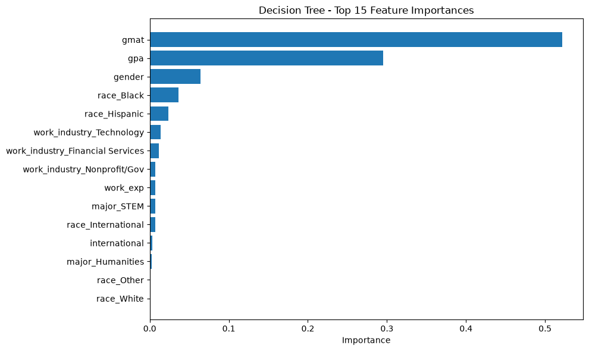

```python
feat_imp_dt = pd.DataFrame({
    'Feature': dt.feature_names_in_,
    'Importance': dt.feature_importances_
}).sort_values(by='Importance', ascending=False)

plt.figure(figsize=(10, 6))
plt.barh(feat_imp_dt['Feature'][:15], feat_imp_dt['Importance'][:15])
plt.xlabel('Importance')
plt.title('Decision Tree - Top 15 Feature Importances')
plt.gca().invert_yaxis()
plt.tight_layout()
plt.show()
```

## Decision Tree - Evaluation

```
=== Decision Tree - Confusion Matrix ===
```

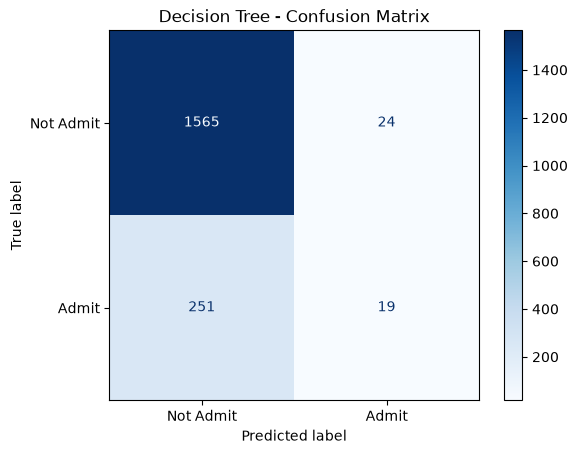

```
=== Decision Tree - Classification Report ===
              precision    recall  f1-score   support

   Not Admit       0.86      0.98      0.92      1589
       Admit       0.44      0.07      0.12       270

    accuracy                           0.85      1859
   macro avg       0.65      0.53      0.52      1859
weighted avg       0.80      0.85      0.80      1859

Decision Tree AUC-ROC: 0.8450
```

```python
from sklearn.metrics import classification_report, confusion_matrix, ConfusionMatrixDisplay, RocCurveDisplay, roc_auc_score

print('=== Decision Tree - Confusion Matrix ===')
cm_dt = confusion_matrix(y_test, y_pred_dt)
ConfusionMatrixDisplay(cm_dt, display_labels=['Not Admit', 'Admit']).plot(cmap='Blues')
plt.title('Decision Tree - Confusion Matrix')
plt.show()

print('\n=== Decision Tree - Classification Report ===')
print(classification_report(y_test, y_pred_dt, target_names=['Not Admit', 'Admit']))

auc_dt = roc_auc_score(y_test, y_prob_dt)
print(f'Decision Tree AUC-ROC: {auc_dt:.4f}')
```

# 5. Random Forest Classifier

```python
%%time
from sklearn.ensemble import RandomForestClassifier

rf = RandomForestClassifier(n_estimators=200, min_samples_leaf=10, max_depth=10, random_state=42)
rf.fit(X_train, y_train)
print('Random Forest trained.')
```

```
Random Forest trained.
CPU times: total: 703 ms
Wall time: 781 ms
```

```python
y_pred_rf = rf.predict(X_test)
y_prob_rf = rf.predict_proba(X_test)[:, 1]
```

## Random Forest - Feature Importance

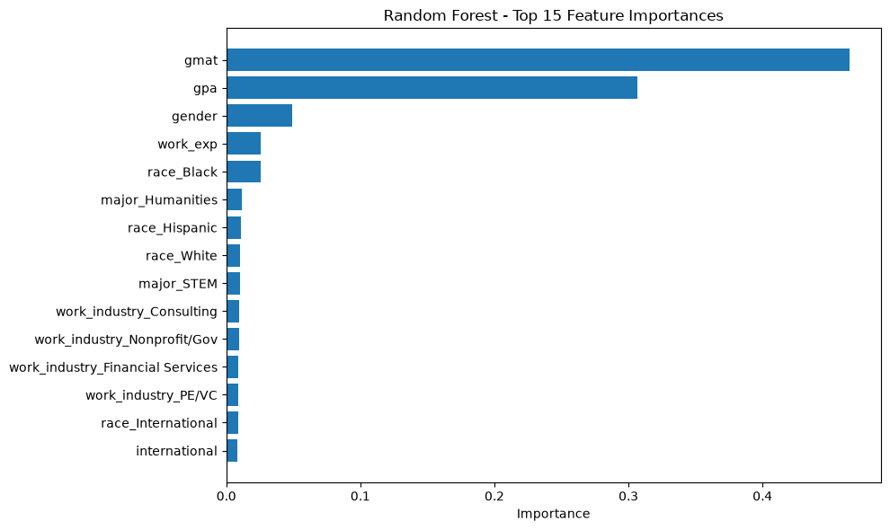

```python
feat_imp_rf = pd.DataFrame({
    'Feature': rf.feature_names_in_,
    'Importance': rf.feature_importances_
}).sort_values(by='Importance', ascending=False)

plt.figure(figsize=(10, 6))
plt.barh(feat_imp_rf['Feature'][:15], feat_imp_rf['Importance'][:15])
plt.xlabel('Importance')
plt.title('Random Forest - Top 15 Feature Importances')
plt.gca().invert_yaxis()
plt.tight_layout()
plt.show()
```

## Random Forest - Evaluation

```
=== Random Forest - Confusion Matrix ===
```

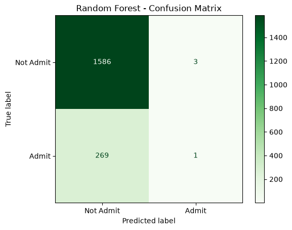

```
=== Random Forest - Classification Report ===
              precision    recall  f1-score   support

   Not Admit       0.85      1.00      0.92      1589
       Admit       0.25      0.00      0.01       270

    accuracy                           0.85      1859
   macro avg       0.55      0.50      0.46      1859
weighted avg       0.77      0.85      0.79      1859

Random Forest AUC-ROC: 0.8499
```

```python
print('=== Random Forest - Confusion Matrix ===')
cm_rf = confusion_matrix(y_test, y_pred_rf)
ConfusionMatrixDisplay(cm_rf, display_labels=['Not Admit', 'Admit']).plot(cmap='Greens')
plt.title('Random Forest - Confusion Matrix')
plt.show()

print('\n=== Random Forest - Classification Report ===')
print(classification_report(y_test, y_pred_rf, target_names=['Not Admit', 'Admit']))

auc_rf = roc_auc_score(y_test, y_prob_rf)
print(f'Random Forest AUC-ROC: {auc_rf:.4f}')
```

# 6. Gradient Boosting Classifier

```python
%%time
from sklearn.ensemble import GradientBoostingClassifier

gb = GradientBoostingClassifier(n_estimators=200, learning_rate=0.1, max_depth=5, min_samples_leaf=10, random_state=42)
gb.fit(X_train, y_train)
print('Gradient Boosting trained.')
```

```
Gradient Boosting trained.
CPU times: total: 1.59 s
Wall time: 1.94 s
```

```python
y_pred_gb = gb.predict(X_test)
y_prob_gb = gb.predict_proba(X_test)[:, 1]
```

## Gradient Boosting - Feature Importance

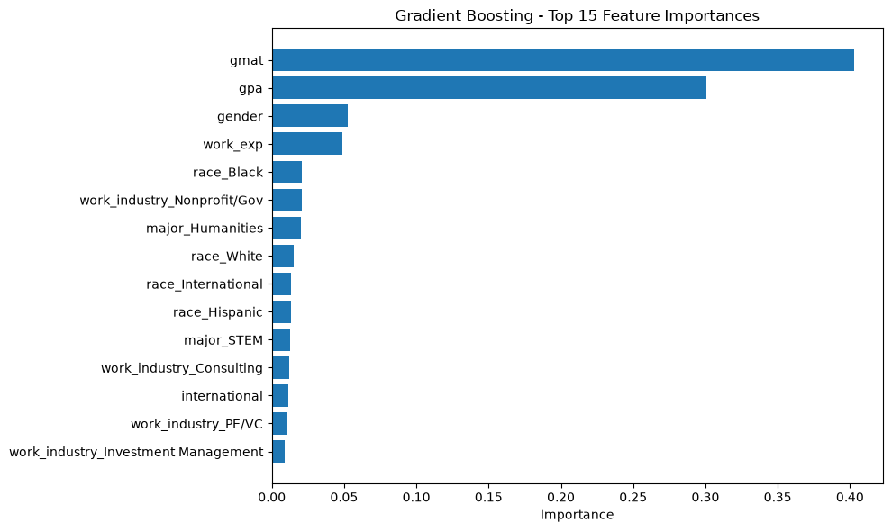

```python
feat_imp_gb = pd.DataFrame({
    'Feature': gb.feature_names_in_,
    'Importance': gb.feature_importances_
}).sort_values(by='Importance', ascending=False)

plt.figure(figsize=(10, 6))
plt.barh(feat_imp_gb['Feature'][:15], feat_imp_gb['Importance'][:15])
plt.xlabel('Importance')
plt.title('Gradient Boosting - Top 15 Feature Importances')
plt.gca().invert_yaxis()
plt.tight_layout()
plt.show()
```

## Gradient Boosting - Evaluation

```
=== Gradient Boosting - Confusion Matrix ===
```

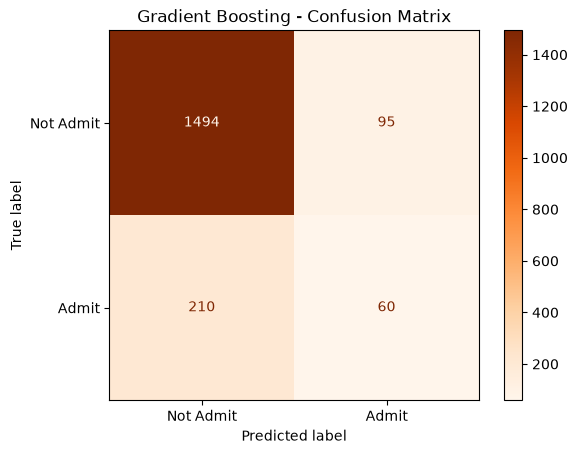

```
=== Gradient Boosting - Classification Report ===
              precision    recall  f1-score   support

   Not Admit       0.88      0.94      0.91      1589
       Admit       0.39      0.22      0.28       270

    accuracy                           0.84      1859
   macro avg       0.63      0.58      0.59      1859
weighted avg       0.81      0.84      0.82      1859

Gradient Boosting AUC-ROC: 0.8419
```

```python
print('=== Gradient Boosting - Confusion Matrix ===')
cm_gb = confusion_matrix(y_test, y_pred_gb)
ConfusionMatrixDisplay(cm_gb, display_labels=['Not Admit', 'Admit']).plot(cmap='Oranges')
plt.title('Gradient Boosting - Confusion Matrix')
plt.show()

print('\n=== Gradient Boosting - Classification Report ===')
print(classification_report(y_test, y_pred_gb, target_names=['Not Admit', 'Admit']))

auc_gb = roc_auc_score(y_test, y_prob_gb)
print(f'Gradient Boosting AUC-ROC: {auc_gb:.4f}')
```

# 7. Model Comparison

```python
from sklearn.metrics import accuracy_score, precision_score, recall_score, f1_score

results = pd.DataFrame({
    'Model': ['Decision Tree', 'Random Forest', 'Gradient Boosting'],
    'Accuracy': [
        accuracy_score(y_test, y_pred_dt),
        accuracy_score(y_test, y_pred_rf),
        accuracy_score(y_test, y_pred_gb)
    ],
    'Precision': [
        precision_score(y_test, y_pred_dt),
        precision_score(y_test, y_pred_rf),
        precision_score(y_test, y_pred_gb)
    ],
    'Recall': [
        recall_score(y_test, y_pred_dt),
        recall_score(y_test, y_pred_rf),
        recall_score(y_test, y_pred_gb)
    ],
    'F1-Score': [
        f1_score(y_test, y_pred_dt),
        f1_score(y_test, y_pred_rf),
        f1_score(y_test, y_pred_gb)
    ],
    'AUC-ROC': [auc_dt, auc_rf, auc_gb]
})

print('=== Model Comparison ===')
results.style.highlight_max(subset=['Accuracy', 'Precision', 'Recall', 'F1-Score', 'AUC-ROC'], color='lightgreen')
```

```
=== Model Comparison ===
```

|  | Model | Accuracy | Precision | Recall | F1-Score | AUC-ROC |
| --- | --- | --- | --- | --- | --- | --- |
| 0 | Decision Tree | 0.852071 | 0.441860 | 0.070370 | 0.121406 | 0.844971 |
| 1 | Random Forest | 0.853685 | 0.250000 | 0.003704 | 0.007299 | 0.849874 |
| 2 | Gradient Boosting | 0.835933 | 0.387097 | 0.222222 | 0.282353 | 0.841854 |

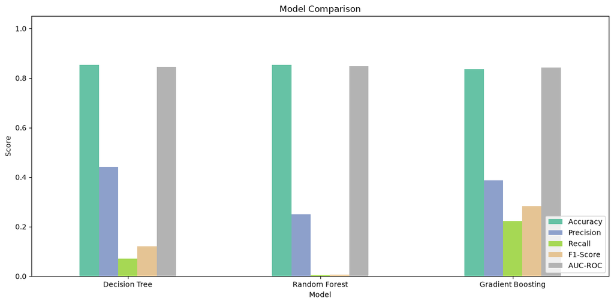

```python
results.set_index('Model').plot(kind='bar', figsize=(12, 6), colormap='Set2')
plt.title('Model Comparison')
plt.ylabel('Score')
plt.ylim(0, 1.05)
plt.xticks(rotation=0)
plt.legend(loc='lower right')
plt.tight_layout()
plt.show()
```

## ROC Curves Comparison

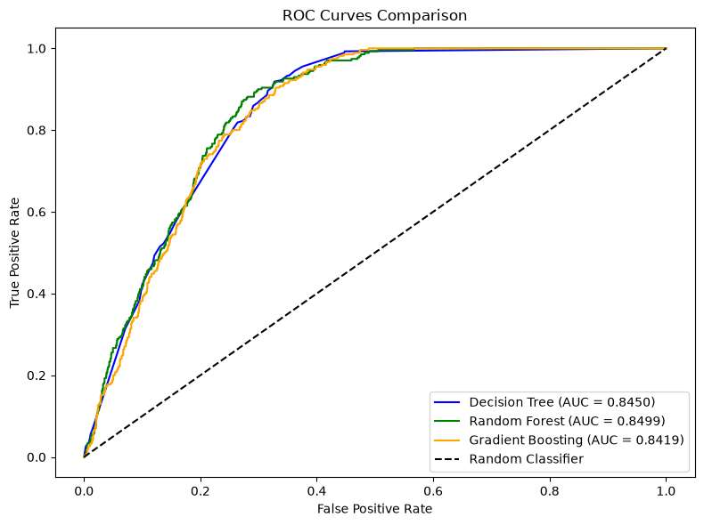

```python
from sklearn.metrics import roc_curve, auc

fig, ax = plt.subplots(figsize=(8, 6))

for name, y_prob, color in [('Decision Tree', y_prob_dt, 'blue'),
                              ('Random Forest', y_prob_rf, 'green'),
                              ('Gradient Boosting', y_prob_gb, 'orange')]:
    fpr, tpr, _ = roc_curve(y_test, y_prob)
    roc_auc = auc(fpr, tpr)
    ax.plot(fpr, tpr, color=color, label=f'{name} (AUC = {roc_auc:.4f})')

ax.plot([0, 1], [0, 1], 'k--', label='Random Classifier')
ax.set_xlabel('False Positive Rate')
ax.set_ylabel('True Positive Rate')
ax.set_title('ROC Curves Comparison')
ax.legend()
plt.tight_layout()
plt.show()
```

## Feature Importance Comparison (Top 10)

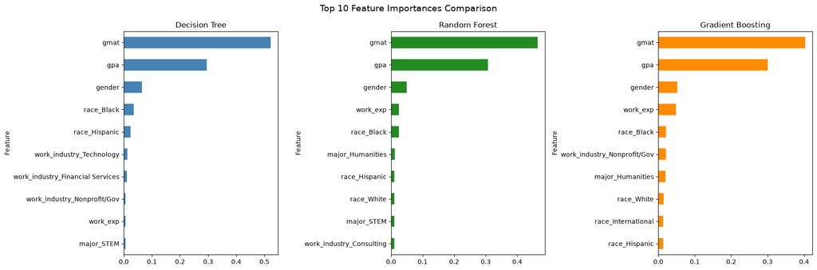

```python
top10_dt = feat_imp_dt.set_index('Feature')['Importance'].head(10)
top10_rf = feat_imp_rf.set_index('Feature')['Importance'].head(10)
top10_gb = feat_imp_gb.set_index('Feature')['Importance'].head(10)

fig, axes = plt.subplots(1, 3, figsize=(18, 6))

top10_dt.plot(kind='barh', ax=axes[0], color='steelblue')
axes[0].set_title('Decision Tree')
axes[0].invert_yaxis()

top10_rf.plot(kind='barh', ax=axes[1], color='forestgreen')
axes[1].set_title('Random Forest')
axes[1].invert_yaxis()

top10_gb.plot(kind='barh', ax=axes[2], color='darkorange')
axes[2].set_title('Gradient Boosting')
axes[2].invert_yaxis()

plt.suptitle('Top 10 Feature Importances Comparison', fontsize=14)
plt.tight_layout()
plt.show()
```

# 8. Summary and Discussion (สรุปและวิจารณ์ผลการทดลอง)

### 8.1 สรุปผลการประเมินโมเดล (Model Performance Evaluation)

จากการทดลองสร้างโมเดลจำแนกผลการรับเข้าเรียน MBA (`Admit = 1`, `Not Admit = 0`) ด้วยวิธี Tree-based ทั้ง 3 โมเดล ได้ผลลัพธ์บน Test Set (Holdout 30%) ดังนี้:

| Model | Accuracy | Precision (Admit) | Recall (Admit) | F1-Score (Admit) | AUC-ROC |
| --- | --- | --- | --- | --- | --- |
| **Decision Tree** | 85.21% | **44.19%** | 7.04% | 12.14% | 0.8450 |
| **Random Forest** | **85.37%** | 25.00% | 0.37% | 0.73% | **0.8499** |
| **Gradient Boosting** | 83.59% | 38.71% | **22.22%** | **28.24%** | 0.8419 |

### 8.2 การวิเคราะห์ปัญหา Class Imbalance และ Accuracy Paradox

1. **ปัญหา Class Imbalance:** ชุดข้อมูลนี้มีอัตราส่วนผู้ผ่านการคัดเลือก (`Admit`) เพียง **14.53%** ขณะที่ผู้ไม่ผ่านมีสูงถึง **85.47%**
2. **Accuracy Paradox:** โมเดล **Random Forest** ให้ Accuracy สูงที่สุด (85.37%) แต่ในความเป็นจริงแทบไม่สามารถทายกลุ่มคนที่ผ่านได้เลย (Recall เพียง 0.37% หรือทายถูกเพียง 1 คนจาก 270 คน) เพราะโมเดลใช้ Default Threshold = 0.5 ซึ่งคะแนนความน่าจะเป็นเฉลี่ยจากต้นไม้ 200 ต้นส่วนใหญ่ไม่แตะ 0.5 ทำให้โมเดลเลือกทายว่า Not Admit เกือบทั้งหมด
3. **โมเดลที่แนะนำ (Best Model):** **Gradient Boosting** เป็นโมเดลที่มีความสมดุลและมีประสิทธิภาพการใช้งานจริงดีที่สุด เพราะให้ **Recall (22.22%)** และ **F1-Score (28.24%)** สูงที่สุด สามารถจับผู้ได้รับการคัดเลือกได้ถึง 60 คน
4. **ศักยภาพในการแยกแยะ (AUC-ROC):** ทุกโมเดลมีค่า AUC-ROC สูงในระดับ **~0.84 - 0.85** แสดงว่าโมเดลมีความสามารถในการจัดลำดับคะแนนความน่าจะเป็น (Probability Ranking) ได้ดีมาก หากนำไปใช้จริงสามารถปรับลด Threshold ลง (เช่น 0.25 - 0.30) เพื่อดึง Recall ให้สูงขึ้นได้

### 8.3 ปัจจัยสำคัญที่สุดในการพิจารณารับเข้าศึกษา (Key Drivers / Feature Importance)

ผลลัพธ์ Feature Importance จากทั้ง 3 โมเดลสอดคล้องกันอย่างมีนัยสำคัญ:

- **อันดับ 1: `gmat` (คะแนนสอบ GMAT):** มีความสำคัญสูงสุด (~40% - 52%) เป็นตัวชี้วัดที่มีอิทธิพลมากที่สุดในการรับเข้าศึกษา
- **อันดับ 2: `gpa` (เกรดเฉลี่ย ป.ตรี):** มีความสำคัญรองลงมา (~30%)
- **อันดับอื่นๆ:** `gender`, `work_exp` (ประสบการณ์ทำงาน), และ `race` มีผลรองลงมาในสัดส่วนรวมกันประมาณ 15% - 20%

### 8.4 ข้อเสนอแนะเพื่อการปรับปรุงโมเดลในอนาคต (Future Improvements)

- ใช้เทคนิคจัดการ Class Imbalance เช่น กำหนด `class_weight='balanced'` หรือทำ Over-sampling ด้วย SMOTE
- ปรับ Decision Threshold ให้เหมาะสมกับบริบทของการคัดเลือกจริง แทนการใช้เกณฑ์ 0.5 แบบคงที่